# Vignette

Allison Warhus 10/5/2021

- Introduction
- Required Packages
- Functions to Interact with the API
  - Here I define functions to interact with the COVID19 API.
- Data Exploration

# Introduction

This is a vignette to demonstrate how to retrieve data from a the COVID19 API. I will use some functions to retrieve and interact with data from the covid API as an example.

# Required Packages

The following packages are required in order to interact with the COVID19 API:  
*[`jsonlite`](https://cran.r-project.org/web/packages/jsonlite/):used for API interaction.  
*[`httr`](https://cran.r-project.org/web/packages/httr/vignettes/quickstart.html): used to map to the http protocol  
These packages are needed to run the functions I have written below.  
*[`tidyverse`](https://www.tidyverse.org/): used for data manipulation and visualization.  
*[`dplyr`](https://dplyr.tidyverse.org/): grammar of data manipulation  
*[`tidyr`](https://tidyr.tidyverse.org/): creates tidy data  
This package is needed to create the plots in the Exploratory Data Analysis section of the vignette.  
*[`ggplot2`](https://ggplot2.tidyverse.org/): a system to create graphics from data.  
[`knitr`](https://yihui.org/knitr/): to build dynamic reports

# Functions to Interact with the API

## Here I define functions to interact with the COVID19 API.

`Total_Cases_Country`  
This function will return the total number of COVID19 cases, deaths and recoveries from a user-specified country. The country can be given as a full country name or a country ID. Data is returned as a data frame.

```r
Total_Cases_Country<-function(country="all"){
  outputAPI<-GET('https://api.covid19api.com/summary')
  data5<-fromJSON(rawToChar(outputAPI$content))
  output<-data5$Countries
  if(country !="all"){
    if(country %in% output$CountryCode){
      output<-output %>%
        filter(CountryCode==country)
    }
    else if (country %in% output$Country){
      output<-output %>%
        filter(Country == country)
    }
    else{
      message<-paste("Error: Country not found")
      stop(message)
    }
  }
  else{
  }
  return(output)
}
```

`Country_By_Date`  
This function will return information about COVID19 based on a user-specified country and for a specific, user-specific month and year (2020 or 2021 only). Data is returned as a data frame.

```r
Country_By_Date<-function(month=1, year=2021,country="Ukraine"){
  URL<-paste0("https://api.covid19api.com/dayone/country/",country)
  outputAPI<-GET(URL)
  data5<-fromJSON(rawToChar(outputAPI$content))
  output<-data5 %>%
    separate("Date", c("Year", "Month","Day+"), sep="-", convert=TRUE, remove=FALSE)
  output<-output %>%
    filter(Year== year) %>%
    filter(Month == month)
  return(output)
}
```

`Number_by_Type`  
This function will return the number of cases of a user-specified type (confirmed cases, active cases, deaths or recovered cases) for a user-specified country from day 1 of the pandemic (3/3/2020). Data is returned as a data frame.

```r
Number_by_Type<-function(type="deaths",country="Ukraine"){
   URL<-paste0("https://api.covid19api.com/dayone/country/",country,"/status/",type)
   outputAPI<-GET(URL)
   data5<-fromJSON(rawToChar(outputAPI$content))
   total<-cumsum(data5$Cases)
   data5<-data5 %>%
     add_column(Total=total)
   return(data5)
}
```

`USA_by_Type`  
This function will return the number of cases of a user-specified type (confirmed cases, active cases,deaths or recovered cases) in the USA.

```r
USA_by_Type<-function(type="Deaths"){
  outputAPI<-GET('https://api.covid19api.com/live/country/USA')
  data<-fromJSON(rawToChar(outputAPI$content))
  if( type != "all"){
    data<-data %>% select(Province,type)
  }
  return(data)
}
```

`findID`  
This function will return the CountryID for a user-specified country. Data is returned as a data frame.

```r
findID<-function(country="all"){
  outputAPI<-GET('https://api.covid19api.com/summary')
  data5<-fromJSON(rawToChar(outputAPI$content))
    output<-data5$Countries
  if(country !="all"){
    if(country %in% output$CountryCode){
      output<-output %>%
        filter(CountryCode==country)
    }
    else if (country %in% output$Country){
      output<-output %>%
        filter(Country == country)
    }
    else{
      message<-paste("Error: Country not found")
      stop(message)
    }
  }
  else{
  }
  df<-data.frame(output$CountryCode)
  return(df)
}
```

`CovidAPI`  
This function is a shortcut to access all other functions I have written. User calls this function and specifies which other function they would like and the data they would like is returned in a data frame.

```r
CovidAPI<-function(func,...){
    if (func == "Total_Cases_Country"){
    output <- Total_Cases_Country(...)
  }
  else if (func == "Country_By_Date"){
    output <- Country_By_Date(...)
  }
  else if (func == "Number_by_Type"){
    output <- Number_by_Type(...)
  }
  else if (func == "USA_by_Type"){
    output <- USA_by_Type(...)
  }
  else if (func == "findID"){
    output <- findID(...)
  }
  else {
    stop("ERROR: Argument for func is not valid!")
  }
  return(output)
}
```

# Data Exploration

Now that we can interact with all endpoints of the Covid19 data, except the premium ones, let’s pull some data and explore it.

First, let’s pull the total number of cases of each type for all countries in the Covid19 database.

```r
casenumbers<-CovidAPI("Total_Cases_Country")
```

I am interested in exploring the relationship between the number of confirmed cases and the number of deaths. I assume these will be positively related.

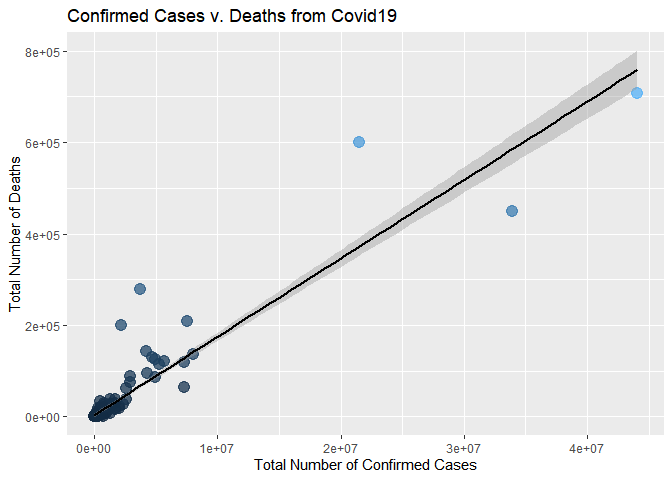

```r
plot1<-ggplot(casenumbers, aes(TotalConfirmed, TotalDeaths, color=TotalDeaths))+geom_point(size=4,alpha=0.75)+
  theme(legend.position="none")+
  geom_smooth(method=lm, formula=y~x, color="black")+
  scale_x_continuous("Total Number of Confirmed Cases")+
  scale_y_continuous("Total Number of Deaths")+
  ggtitle("Confirmed Cases v. Deaths from Covid19")
plot1
```

We can see that there is a positive relationship between Confirmed Cases and Number of Deaths. A lot of the data is clustered in the lower left hand corner with three points far away from the others. I suspect these points are influential and further analysis should be done.

This plot has far too many countries on it to yield meaningful results. I am going to recreate the scatterplot but only include countries that are in the Americas.

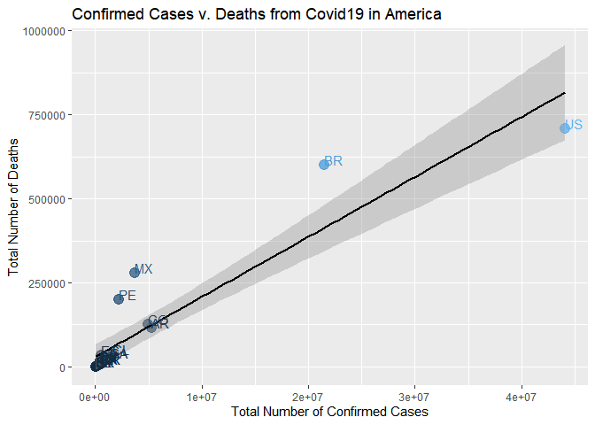

```r
Americas<-casenumbers %>% filter(CountryCode %in% c("MX","CA","US","BZ","CR","SV","GT","HN","AR","BO","BR","CL","CO","EC","GY","PE","NI","PA","PY","SR","UY"))
plot2<-ggplot(Americas, aes(TotalConfirmed, TotalDeaths, color=TotalDeaths, ))+
  geom_point(size=4,alpha=0.75)+
  theme(legend.position="none")+
  geom_smooth(method=lm, formula=y~x, color="black")+
  scale_x_continuous("Total Number of Confirmed Cases")+
  scale_y_continuous("Total Number of Deaths")+
  ggtitle("Confirmed Cases v. Deaths from Covid19 in America")+
  geom_text(aes(label=CountryCode),hjust=0, vjust=0)
plot2
```

We can see that two of the three points which I suspect to be influential are from the Americas. I labeled the points with their Country Code from the data. I used Country Code rather than Country so that the labels would be more readable on the graph. These labels reveal that Brazil and the US are the two points of interest. Both countries have a high number of confirmed cases relative to the other countries included on this plot. However, Brazil has a higher number of deaths than the statistical model would predict while the US has a lower number, but still within the expected range.

Continuing to narrow our focus to just all provinces in the US, let’s explore the percent of confirmed cases that end in death. I will create a histogram to display this data. The x-axis represents the percent of cases that end in death. That is 1 on the x-axis means that 1% of confirmed cases ended in death.

```
## Warning: Removed 2 rows containing non-finite values (stat_bin).
```

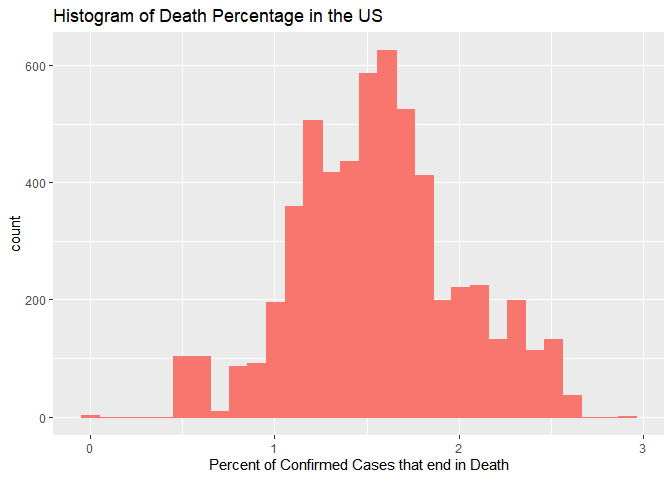

```r
deathpercentage<-USA_by_Type(type="all")
percentage<-(deathpercentage$Deaths/deathpercentage$Confirmed)*100
plot3<-ggplot(deathpercentage,aes(percentage, col="blue",fill="green"))+
  geom_histogram()+
  theme(legend.position="none")+
  scale_x_continuous(
    "Percent of Confirmed Cases that end in Death")+
  ggtitle("Histogram of Death Percentage in the US")
plot3
```

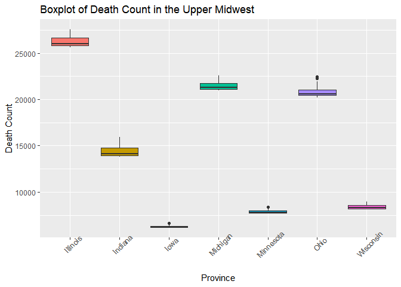

```r
midwest<-USA_by_Type("Deaths")
midwest<-midwest %>%
          filter(Province %in%
              c("Illinois","Indiana","Iowa","Michigan",
                "Minnesota","Ohio","Wisconsin"))
df<-as.data.frame(midwest)
plot4<-ggplot(midwest,aes(x=Province, y=Deaths, fill=Province))+
  geom_boxplot()+
  scale_y_continuous("Death Count")+
  ggtitle("Boxplot of Death Count in the Upper Midwest")+
  theme(axis.text.x=element_text(angle=45), legend.position="none")
plot4
```

This graph has such a wide range on the y-axis that it’s difficult to interpret. Let’s explore the 5 number summary for deaths in midwestern states. That will give us the same information but in table format which may be easier to understand.

```r
midwestSumm<-midwest %>% group_by(Province) %>%
  summarize("Min"=min(Deaths),
            "1st Quartile"=quantile(Deaths,0.25),
            "Median"=quantile(Deaths,0.5),
            "3rd Quartile"=quantile(Deaths,0.75),
            "Max"=max(Deaths)
            )
knitr ::kable(midwestSumm)
```

| Province | Min | 1st Quartile | Median | 3rd Quartile | Max |
| --- | --- | --- | --- | --- | --- |
| Illinois | 25624 | 25814.50 | 26027 | 26659.50 | 27586 |
| Indiana | 13819 | 13956.50 | 14128 | 14765.00 | 15921 |
| Iowa | 6124 | 6158.00 | 6210 | 6337.00 | 6651 |
| Michigan | 20945 | 21120.25 | 21284 | 21773.75 | 22609 |
| Minnesota | 7654 | 7731.75 | 7822 | 7971.50 | 8356 |
| Ohio | 20213 | 20446.00 | 20614 | 21053.50 | 22490 |
| Wisconsin | 8092 | 8211.25 | 8322 | 8595.00 | 8970 |

Since the count of deaths is so varied, the y scale on my boxplots makes the graphs not as useful as they could be. The table helps, but it’s a lot of numbers to interpret. I am going to create a barplot that shows the count of deaths for each upper midwestern state. I believe this will make the comparison easier.

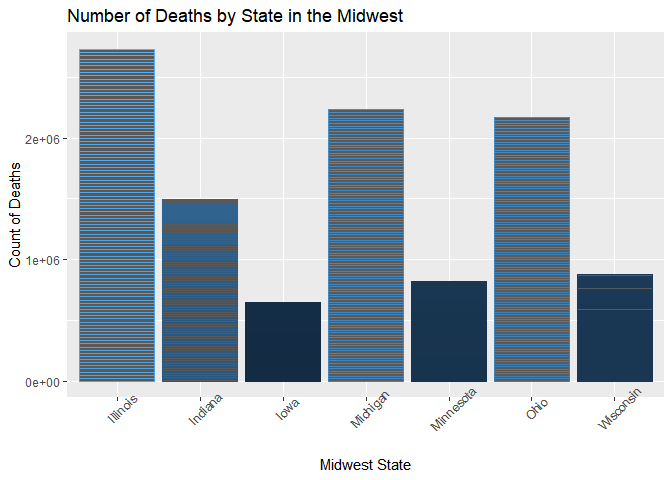

```r
midwest<-USA_by_Type("Deaths")
midwest<-midwest %>%
          filter(Province %in%
              c("Illinois","Indiana","Iowa","Michigan",
                "Minnesota","Ohio","Wisconsin"))
plot5<-ggplot(midwest, aes(Province, Deaths, color=Deaths))+
  geom_col()+scale_x_discrete("Midwest State")+
  scale_y_continuous("Count of Deaths")+
  ggtitle("Number of Deaths by State in the Midwest")+
  theme(axis.text.x=element_text(angle=45), legend.position="none")
plot5
```

This plot does make comparing the count of deaths easier than the boxplot. Illinois has the highest number of deaths and Iowa has the least.

Looking at the number of deaths from COVID19 may only be helpful if we have a way to determine if the number of deaths is significant. I created a variable called deathcount to classify the number of deaths to minimal, significant and severe. Let’s look at this classification in a contingency table.

```r
midwest<- midwest %>%
  mutate(deathcount = ifelse(Deaths <10000, "minimal",
                      ifelse(Deaths <=15000, "significant",
                             "severe")))
table(midwest$Province, midwest$deathcount)
```

```
##
##             minimal severe significant
##   Illinois        0    104           0
##   Indiana         0     21          83
##   Iowa          104      0           0
##   Michigan        0    104           0
##   Minnesota     104      0           0
##   Ohio            0    104           0
##   Wisconsin     104      0           0
```

This table echos what the barplot showed. Indiana is our only “in between” state in terms of death count. Illinois, Michigan and Ohio are the severe states while the rest are minimal in terms of death count.

Here is my render code. I used this to render my document without pressing the knit button.

```r
rmarkdown::render("C:/Users/ejwar/Desktop/Project1/Vignettev2.Rmd",
  output_format = "github_document",
  output_options = list(toc = TRUE, toc_depth = '2', toc_float= TRUE),
  output_file= "README.md")
```